# Module 1: Tabular Data

Working with larger-than-RAM data using duckdbfs

Author

ESPM 288

## Introduction

In this module, we will explore high-performance workflows for tabular data. We will use `duckdbfs` to work with datasets that are larger than available RAM by leveraging DuckDB’s streaming and remote file access capabilities.

## Case Study: Global Supply Chains

We will be working with [EXIOBASE 3.8.1](https://source.coop/youssef-harby/exiobase-3), a global Multi-Regional Input-Output (MRIO) database. This dataset tracks economic transactions between sectors and regions, along with their environmental impacts (emissions, resource use, etc.).

**Data description:** - **Coverage**: 44 countries + 5 rest-of-world regions. - **Timeframe**: 1995–2022. - **Content**: Economic transactions (Z matrix), final demand (Y matrix), and environmental stressors (F matrix). - **Format**: Cloud-optimized Parquet, partitioned by year and matrix type.

## Setup

```r
library(duckdbfs)
library(dplyr)
```

## Exercise 1: connecting to remote data

We can open the entire dataset without downloading it using `open_dataset()`. The data is hosted on Source Cooperative. The `**` pattern allows recursive scanning of the partitioned parquet files.

```r
# Remote S3 path to EXIOBASE 3 (Source Cooperative)
duckdbfs::duckdb_secrets(
    key = "",
    secret = "",
    endpoint = "s3.amazonaws.com",
    region = "us-west-2"
)
```

```
[1] 1
```

```r
s3_url <- "s3://us-west-2.opendata.source.coop/youssef-harby/exiobase-3/4588235/parquet/**"

# Open the dataset lazily
exio <- open_dataset(s3_url)

# View the schema (column names and types) without reading data
glimpse(exio)
```

```
Rows: ??
Columns: 8
Database: DuckDB 1.4.3 [ltsta@Windows 10 x64:R 4.5.2/:memory:]
$ stressor <chr> "Value Added", "Value Added", "Value Added", "Value Added", "…
$ region   <chr> "AT", "AT", "AT", "AT", "AT", "AT", "AT", "AT", "AT", "AT", "…
$ sector   <chr> "Cultivation of wheat", "Cultivation of cereal grains nec", "…
$ value    <dbl> 183.1118891, 402.2305799, 830.2127384, 101.9705426, 31.763189…
$ unit     <chr> "M.EUR", "M.EUR", "M.EUR", "M.EUR", "M.EUR", "M.EUR", "M.EUR"…
$ year     <dbl> 1995, 1995, 1995, 1995, 1995, 1995, 1995, 1995, 1995, 1995, 1…
$ format   <chr> "ixi", "ixi", "ixi", "ixi", "ixi", "ixi", "ixi", "ixi", "ixi"…
$ matrix   <chr> "F_impacts", "F_impacts", "F_impacts", "F_impacts", "F_impact…
```

## Exercise 2: Efficient Filtering

The dataset is large. We should filter *before* collecting any data into R.

```r
exio |>
    filter(year == 2022, region == "US") |>
    head() |> # view the first 6 rows
    collect()
```

| stressor | region | sector | value | unit | year | format | matrix |
| --- | --- | --- | --- | --- | --- | --- | --- |
| Value Added | US | Cultivation of paddy rice | 749.9572 | M.EUR | 2022 | ixi | F_impacts |
| Value Added | US | Cultivation of wheat | 2019.0505 | M.EUR | 2022 | ixi | F_impacts |
| Value Added | US | Cultivation of cereal grains nec | 7354.9033 | M.EUR | 2022 | ixi | F_impacts |
| Value Added | US | Cultivation of vegetables, fruit, nuts | 26877.5032 | M.EUR | 2022 | ixi | F_impacts |
| Value Added | US | Cultivation of oil seeds | 5002.8604 | M.EUR | 2022 | ixi | F_impacts |
| Value Added | US | Cultivation of sugar cane, sugar beet | 290.0846 | M.EUR | 2022 | ixi | F_impacts |

## Exercise 3: CO2 Emissions Analysis

Read CO2 emissions data from the F_satellite matrix and analyze top sectors.

```r
# Read CO2 production data from F_satellite matrix
# Filter for CO2-related stressors in 2022
co2_data <- exio |>
    filter(
        year == 2022,
        matrix == "F_satellite",
        stressor %like% "%CO2%"
    ) |>
    collect()

# View the CO2 data
co2_data
```

| stressor | region | sector | value | unit | year | format | matrix |
| --- | --- | --- | --- | --- | --- | --- | --- |
| CO2 - combustion - air | AT | Cultivation of wheat | 2.401531e+08 | kg | 2022 | ixi | F_satellite |
| CO2 - combustion - air | AT | Cultivation of cereal grains nec | 2.271071e+08 | kg | 2022 | ixi | F_satellite |
| CO2 - combustion - air | AT | Cultivation of vegetables, fruit, nuts | 9.838481e+07 | kg | 2022 | ixi | F_satellite |
| CO2 - combustion - air | AT | Cultivation of oil seeds | 4.809213e+07 | kg | 2022 | ixi | F_satellite |
| CO2 - combustion - air | AT | Cultivation of sugar cane, sugar beet | 1.291156e+07 | kg | 2022 | ixi | F_satellite |
| CO2 - combustion - air | AT | Cultivation of plant-based fibers | 1.118579e+04 | kg | 2022 | ixi | F_satellite |
| CO2 - combustion - air | AT | Cultivation of crops nec | 1.972192e+06 | kg | 2022 | ixi | F_satellite |
| CO2 - combustion - air | AT | Cattle farming | 9.264802e+07 | kg | 2022 | ixi | F_satellite |
| CO2 - combustion - air | AT | Pigs farming | 5.568041e+07 | kg | 2022 | ixi | F_satellite |
| CO2 - combustion - air | AT | Poultry farming | 5.066570e+07 | kg | 2022 | ixi | F_satellite |

[output cut: 9990 more lines]

```r
glimpse(co2_data)
```

```
Rows: 35,334
Columns: 8
$ stressor <chr> "CO2 - combustion - air", "CO2 - combustion - air", "CO2 - co…
$ region   <chr> "AT", "AT", "AT", "AT", "AT", "AT", "AT", "AT", "AT", "AT", "…
$ sector   <chr> "Cultivation of wheat", "Cultivation of cereal grains nec", "…
$ value    <dbl> 2.401531e+08, 2.271071e+08, 9.838481e+07, 4.809213e+07, 1.291…
$ unit     <chr> "kg", "kg", "kg", "kg", "kg", "kg", "kg", "kg", "kg", "kg", "…
$ year     <dbl> 2022, 2022, 2022, 2022, 2022, 2022, 2022, 2022, 2022, 2022, 2…
$ format   <chr> "ixi", "ixi", "ixi", "ixi", "ixi", "ixi", "ixi", "ixi", "ixi"…
$ matrix   <chr> "F_satellite", "F_satellite", "F_satellite", "F_satellite", "…
```

```r
# Find unique CO2 stressors
unique_stressors <- co2_data |>
    distinct(stressor) |>
    arrange(stressor)

unique_stressors
```

| stressor |
| --- |
| CO2 - agriculture - peat decay - air |
| CO2 - combustion - air |
| CO2 - non combustion - Cement production - air |
| CO2 - non combustion - Lime production - air |
| CO2 - waste - biogenic - air |
| CO2 - waste - fossil - air |

## Exercise 3: Time Series Analysis of Top CO2 Emitters

Now let’s create a visualization showing CO2 emissions over time for the top 5 emitting countries.

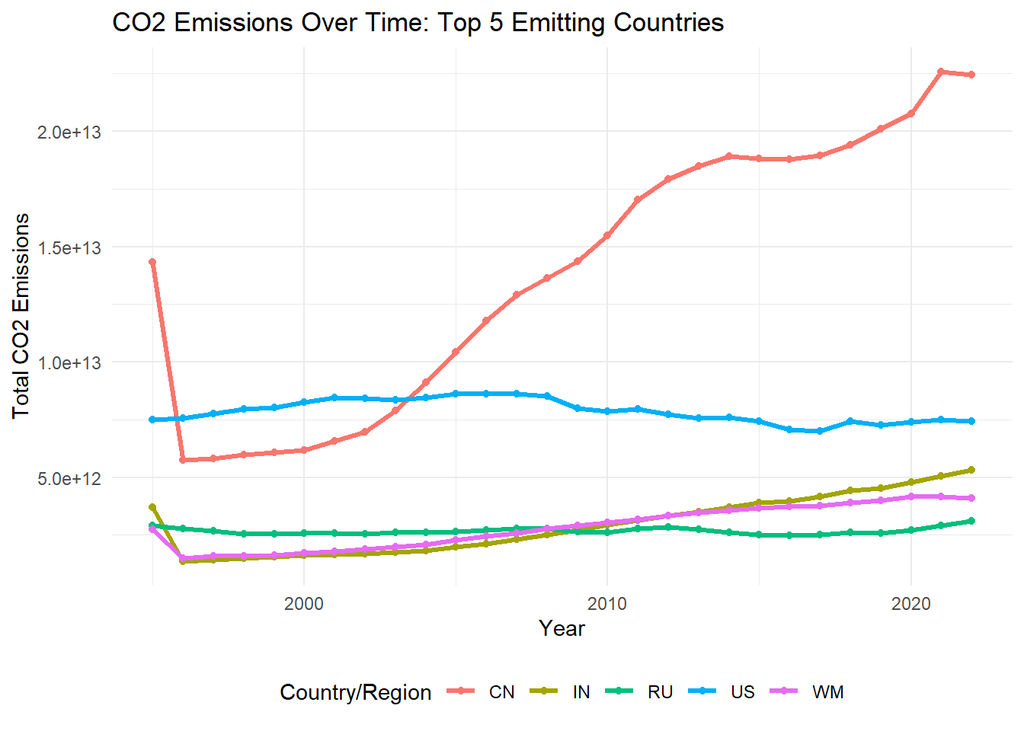

```r
library(ggplot2)

# Get CO2 data, identify top 5 emitters, and create time series
exio |>
    filter(matrix == "F_satellite", stressor %like% "%CO2%") |>
    collect() |>
    group_by(region) |>
    mutate(region_total = sum(value, na.rm = TRUE)) |>
    ungroup() |>
    filter(dense_rank(desc(region_total)) <= 5) |>
    group_by(year, region) |>
    summarize(total_co2 = sum(value, na.rm = TRUE), .groups = "drop") |>
    ggplot(aes(x = year, y = total_co2, color = region)) +
    geom_line(linewidth = 1.2) +
    geom_point(linewidth = 2) +
    labs(
        title = "CO2 Emissions Over Time: Top 5 Emitting Countries",
        x = "Year",
        y = "Total CO2 Emissions",
        color = "Country/Region"
    ) +
    theme_minimal() +
    theme(legend.position = "bottom")
```

## Exercise 4: Top Countries Reducing CO2 Emissions

Let’s identify the countries that have achieved the greatest reduction in CO2 emissions from 1995 to 2022.

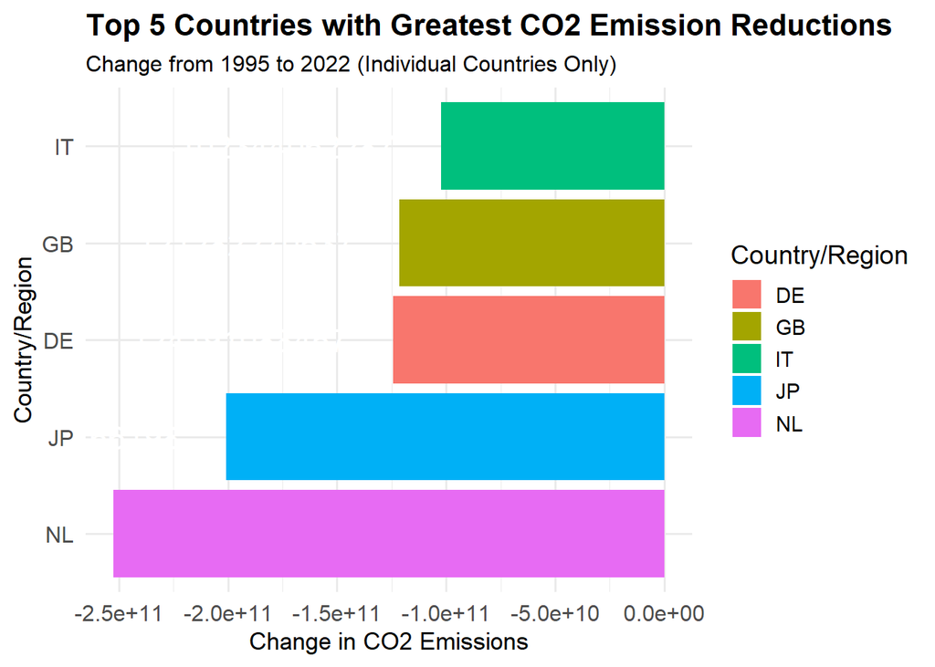

```r
# Calculate emission changes and identify top 5 reducers (individual countries only)
exio |>
    filter(matrix == "F_satellite", stressor %like% "%CO2%") |>
    collect() |>
    filter(!region %in% c("WE", "WA", "WF", "WL", "WM")) |>  # Exclude aggregated regions
    group_by(year, region) |>
    summarize(total_co2 = sum(value, na.rm = TRUE), .groups = "drop") |>
    group_by(region) |>
    filter(n() >= 2) |>  # Ensure at least 2 years of data
    summarize(
        first_year_emissions = total_co2[which.min(year)],
        last_year_emissions = total_co2[which.max(year)],
        change = last_year_emissions - first_year_emissions,
        .groups = "drop"
    ) |>
    arrange(change) |>
    head(5) |>
    ggplot(aes(x = reorder(region, change), y = change, fill = region)) +
    geom_col() +
    geom_text(aes(label = round(change, 0)), hjust = 1.2, color = "white", size = 6) +
    coord_flip() +
    labs(
        title = "Top 5 Countries with Greatest CO2 Emission Reductions",
        subtitle = "Change from 1995 to 2022 (Individual Countries Only)",
        x = "Country/Region",
        y = "Change in CO2 Emissions",
        fill = "Country/Region"
    ) +
    theme_minimal(base_size = 14) +
    theme(
        legend.position = "right",
        plot.title = element_text(size = 16, face = "bold"),
        plot.subtitle = element_text(size = 12),
        axis.text = element_text(size = 12),
        axis.title = element_text(size = 13)
    )
```

```r
# Find top 5 sectors in the US by CO2 emissions in 2022
top_co2_sectors <- co2_data |>
    filter(region == "US") |>
    group_by(sector) |>
    summarise(total_co2 = sum(value, na.rm = TRUE)) |>
    arrange(desc(total_co2)) |>
    slice_head(n = 5)

top_co2_sectors
```

| sector | total_co2 |
| --- | --- |
| Production of electricity by coal | 1.380196e+12 |
| Electricity by coal | 1.184873e+12 |
| Production of electricity by gas | 6.967603e+11 |
| Electricity by gas | 6.325846e+11 |
| Chemicals nec | 2.187124e+11 |

## Exercise 4: Time Series of Top CO2 Emitting Countries

Visualize CO2 emissions over time for the top 5 emitting countries.

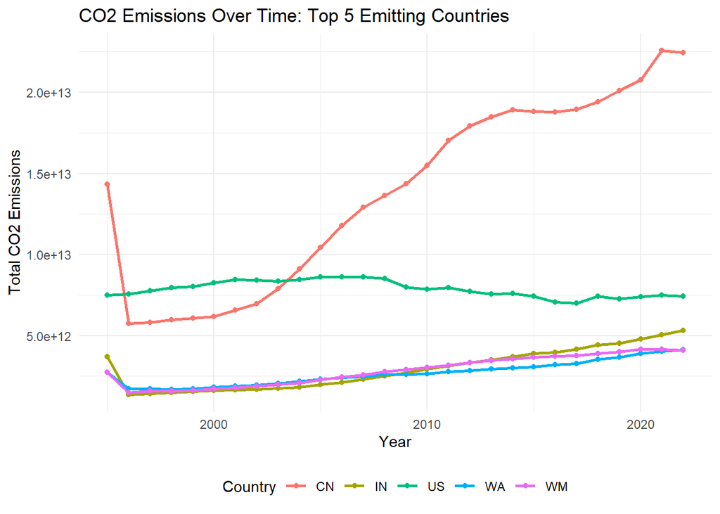

```r
library(ggplot2)

# First, get all CO2 data across all years
co2_all_years <- exio |>
    filter(
        matrix == "F_satellite",
        stressor %like% "%CO2%"
    ) |>
    collect()

# Identify top 5 CO2 emitting countries in 2022
top_5_countries <- co2_all_years |>
    filter(year == 2022) |>
    group_by(region) |>
    summarise(total_co2 = sum(value, na.rm = TRUE)) |>
    arrange(desc(total_co2)) |>
    slice_head(n = 5) |>
    pull(region)

# Filter data for top 5 countries across all years
co2_time_series <- co2_all_years |>
    filter(region %in% top_5_countries) |>
    group_by(year, region) |>
    summarise(total_co2 = sum(value, na.rm = TRUE), .groups = "drop")

# Create the plot
ggplot(co2_time_series, aes(x = year, y = total_co2, color = region)) +
    geom_line(linewidth = 1) +
    geom_point() +
    labs(
        title = "CO2 Emissions Over Time: Top 5 Emitting Countries",
        x = "Year",
        y = "Total CO2 Emissions",
        color = "Country"
    ) +
    theme_minimal() +
    theme(legend.position = "bottom")
```

## Exercise 5: Top CO2 Emitting Industries Globally

Identify the top 5 industries/sectors that emit the most CO2 globally in 2022.

```r
# Find top 5 industries globally by CO2 emissions in 2022
top_co2_industries <- co2_data |>
    group_by(sector) |>
    summarise(total_co2 = sum(value, na.rm = TRUE)) |>
    arrange(desc(total_co2)) |>
    slice_head(n = 5)

top_co2_industries
```

| sector | total_co2 |
| --- | --- |
| Production of electricity by coal | 8.333978e+12 |
| Electricity by coal | 7.304115e+12 |
| Cement, lime and plaster | 2.589230e+12 |
| Manufacture of cement, lime and plaster | 2.541866e+12 |
| Production of electricity by gas | 2.301629e+12 |

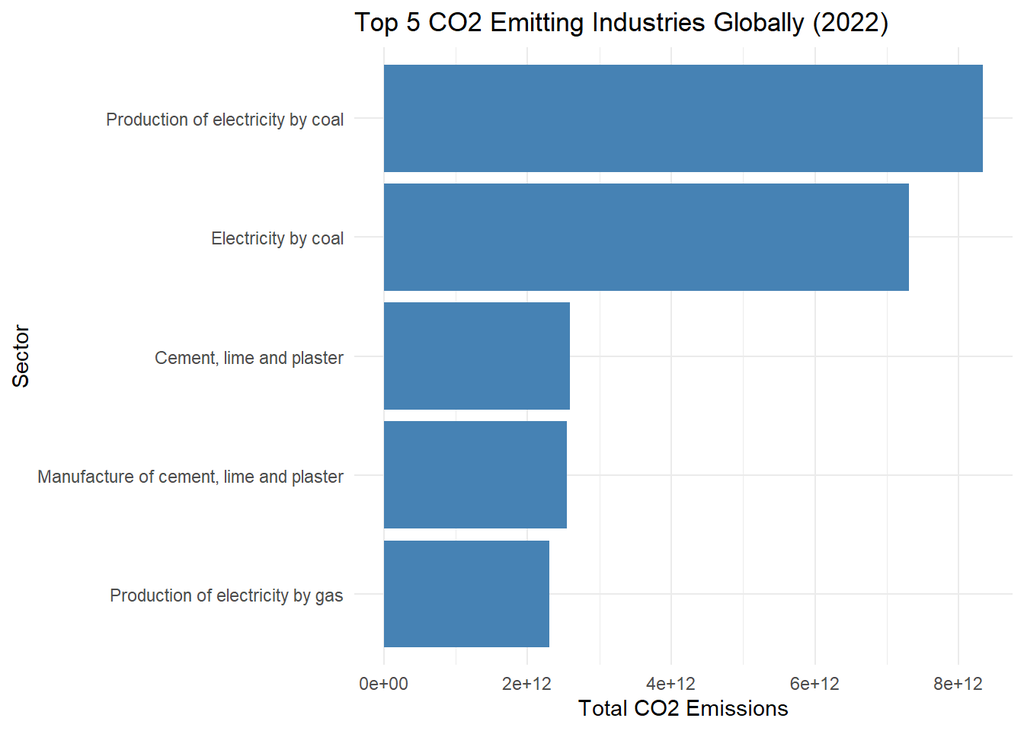

```r
# Visualize top 5 emitting industries
ggplot(top_co2_industries, aes(x = reorder(sector, total_co2), y = total_co2)) +
    geom_col(fill = "steelblue") +
    coord_flip() +
    labs(
        title = "Top 5 CO2 Emitting Industries Globally (2022)",
        x = "Sector",
        y = "Total CO2 Emissions"
    ) +
    theme_minimal()
```

## Exercise 6: types of pollutants

In the US, what are the top 5 sectors with highest emissions in 2022?

```r
# Find top 5 sectors with highest total emissions in the US in 2022
top_us_sectors <- exio |>
    filter(year == 2022, matrix == "F_satellite", region == "US") |>
    collect() |>
    group_by(sector) |>
    summarise(total_emissions = sum(value, na.rm = TRUE), .groups = "drop") |>
    arrange(desc(total_emissions)) |>
    slice_head(n = 5)

top_us_sectors
```

| sector | total_emissions |
| --- | --- |
| Production of electricity by coal | 1.386936e+12 |
| Electricity by coal | 1.191077e+12 |
| Production of electricity by gas | 6.981660e+11 |
| Electricity by gas | 6.338720e+11 |
| Chemicals nec | 2.227753e+11 |